# Semi-Confirmatory Factor Analysis

Po-Hsien Huang

In this example, we will show how to use `lslx` to conduct semi-confirmatory factor analysis. The example uses data `HolzingerSwineford1939` in the package `lavaan`. Hence, `lavaan` must be installed.

## Model Sepcification

In the following specification, `x1` - `x9` is assumed to be measurements of 3 latent factors: `visual`, `textual`, and `speed`.

```r
model <-
'
visual  :=> x1 + x2 + x3
textual :=> x4 + x5 + x6
speed   :=> x7 + x8 + x9
visual  :~> x4 + x5 + x6 + x7 + x8 + x9
textual :~> x1 + x2 + x3 + x7 + x8 + x9
speed   :~> x1 + x2 + x3 + x4 + x5 + x6
visual  <=> fix(1) * visual
textual <=> fix(1) * textual
speed   <=> fix(1) * speed
'
```

## Object Initialization

`lslx` is written as an `R6` class. Everytime we conduct analysis with `lslx`, an `lslx` object must be initialized. The following code initializes an `lslx` object named `r6_lslx`.

```r
library(lslx)
r6_lslx <- lslx$new(model = model,
                    data = lavaan::HolzingerSwineford1939)
```

```
An 'lslx' R6 class is initialized via 'data'.
  Response Variable(s): x1 x2 x3 x4 x5 x6 x7 x8 x9
  Latent Factor(s): visual textual speed
```

To see the model specification, we may use the `extract_specification` method.

```r
r6_lslx$extract_specification()
```

```
                             relation    left   right group reference matrice block  type start
x1<-1|G                         x1<-1      x1       1     G     FALSE   alpha  y<-1  free    NA
x2<-1|G                         x2<-1      x2       1     G     FALSE   alpha  y<-1  free    NA
x3<-1|G                         x3<-1      x3       1     G     FALSE   alpha  y<-1  free    NA
x4<-1|G                         x4<-1      x4       1     G     FALSE   alpha  y<-1  free    NA
x5<-1|G                         x5<-1      x5       1     G     FALSE   alpha  y<-1  free    NA
x6<-1|G                         x6<-1      x6       1     G     FALSE   alpha  y<-1  free    NA
x7<-1|G                         x7<-1      x7       1     G     FALSE   alpha  y<-1  free    NA
x8<-1|G                         x8<-1      x8       1     G     FALSE   alpha  y<-1  free    NA
x9<-1|G                         x9<-1      x9       1     G     FALSE   alpha  y<-1  free    NA
x1<-visual|G               x1<-visual      x1  visual     G     FALSE    beta  y<-f  free    NA
x2<-visual|G               x2<-visual      x2  visual     G     FALSE    beta  y<-f  free    NA
x3<-visual|G               x3<-visual      x3  visual     G     FALSE    beta  y<-f  free    NA
x4<-visual|G               x4<-visual      x4  visual     G     FALSE    beta  y<-f   pen    NA
x5<-visual|G               x5<-visual      x5  visual     G     FALSE    beta  y<-f   pen    NA
x6<-visual|G               x6<-visual      x6  visual     G     FALSE    beta  y<-f   pen    NA
x7<-visual|G               x7<-visual      x7  visual     G     FALSE    beta  y<-f   pen    NA
x8<-visual|G               x8<-visual      x8  visual     G     FALSE    beta  y<-f   pen    NA
x9<-visual|G               x9<-visual      x9  visual     G     FALSE    beta  y<-f   pen    NA
x1<-textual|G             x1<-textual      x1 textual     G     FALSE    beta  y<-f   pen    NA
x2<-textual|G             x2<-textual      x2 textual     G     FALSE    beta  y<-f   pen    NA
x3<-textual|G             x3<-textual      x3 textual     G     FALSE    beta  y<-f   pen    NA
x4<-textual|G             x4<-textual      x4 textual     G     FALSE    beta  y<-f  free    NA
x5<-textual|G             x5<-textual      x5 textual     G     FALSE    beta  y<-f  free    NA
x6<-textual|G             x6<-textual      x6 textual     G     FALSE    beta  y<-f  free    NA
x7<-textual|G             x7<-textual      x7 textual     G     FALSE    beta  y<-f   pen    NA
x8<-textual|G             x8<-textual      x8 textual     G     FALSE    beta  y<-f   pen    NA
x9<-textual|G             x9<-textual      x9 textual     G     FALSE    beta  y<-f   pen    NA
x1<-speed|G                 x1<-speed      x1   speed     G     FALSE    beta  y<-f   pen    NA
x2<-speed|G                 x2<-speed      x2   speed     G     FALSE    beta  y<-f   pen    NA
x3<-speed|G                 x3<-speed      x3   speed     G     FALSE    beta  y<-f   pen    NA
x4<-speed|G                 x4<-speed      x4   speed     G     FALSE    beta  y<-f   pen    NA
x5<-speed|G                 x5<-speed      x5   speed     G     FALSE    beta  y<-f   pen    NA
x6<-speed|G                 x6<-speed      x6   speed     G     FALSE    beta  y<-f   pen    NA
x7<-speed|G                 x7<-speed      x7   speed     G     FALSE    beta  y<-f  free    NA
x8<-speed|G                 x8<-speed      x8   speed     G     FALSE    beta  y<-f  free    NA
x9<-speed|G                 x9<-speed      x9   speed     G     FALSE    beta  y<-f  free    NA
visual<->visual|G     visual<->visual  visual  visual     G     FALSE     psi f<->f fixed     1
textual<->visual|G   textual<->visual textual  visual     G     FALSE     psi f<->f  free    NA
speed<->visual|G       speed<->visual   speed  visual     G     FALSE     psi f<->f  free    NA
textual<->textual|G textual<->textual textual textual     G     FALSE     psi f<->f fixed     1
speed<->textual|G     speed<->textual   speed textual     G     FALSE     psi f<->f  free    NA
speed<->speed|G         speed<->speed   speed   speed     G     FALSE     psi f<->f fixed     1
x1<->x1|G                     x1<->x1      x1      x1     G     FALSE     psi y<->y  free    NA
x2<->x2|G                     x2<->x2      x2      x2     G     FALSE     psi y<->y  free    NA
x3<->x3|G                     x3<->x3      x3      x3     G     FALSE     psi y<->y  free    NA
x4<->x4|G                     x4<->x4      x4      x4     G     FALSE     psi y<->y  free    NA
x5<->x5|G                     x5<->x5      x5      x5     G     FALSE     psi y<->y  free    NA
x6<->x6|G                     x6<->x6      x6      x6     G     FALSE     psi y<->y  free    NA
x7<->x7|G                     x7<->x7      x7      x7     G     FALSE     psi y<->y  free    NA
x8<->x8|G                     x8<->x8      x8      x8     G     FALSE     psi y<->y  free    NA
x9<->x9|G                     x9<->x9      x9      x9     G     FALSE     psi y<->y  free    NA
```

The row names show the coefficient names. The most two relevant columns are `type` which shows the type of the coefficient and `start` which gives the starting value. In `lslx`, many `extract` related methods are defined. `extract` related methods can be used to extract quantities stored in `lslx` object. For details, please see the the section of Extract-Related Methods via `?lslx`.

## Model Fitting

After an `lslx` object is initialized, method `fit` can be used to fit the specified model to the given data.

```r
r6_lslx$fit(penalty_method = "mcp",
            lambda_grid = seq(.01, .30, .01),
            delta_grid = c(5, 10))
```

```
CONGRATS: The algorithm converged under all specified penalty levels.
  Specified Tolerance for Convergence: 0.001
  Specified Maximal Number of Iterations: 100
```

The fitting process requires users to specify the penalty method (argument `penalty_method`) and the considerd penalty levels (argument `lambda_grid` and `delta_grid`). In this example, the `mcp` penalty is implemented on the lambda grid `seq(.01, .30, .01)` and delta grid `c(5, 10)`. Note that in this example `lambda = 0` is not considered because it may result in unidentified model. All the fitting result will be stored in the `fitting` field of `r6_lslx`.

## Model Summarizing

Unlike traditional SEM analysis, `lslx` fits the model into data under all the penalty levels considered. To summarize the fitting result, a selector to determine an optimal penalty level must be specified. Availble selectors can be found in the section of Penalty Level Selection via `?lslx`. The following code summarize the fitting result under the penalty level selected by Bayesian information criterion (BIC).

```r
r6_lslx$summarize(selector = "bic")
```

```
General Information
   number of observations                                               301
   number of complete observations                                      301
   number of missing patterns                                          none
   number of groups                                                       1
   number of responses                                                    9
   number of factors                                                      3
   number of free coefficients                                           30
   number of penalized coefficients                                      18

Fitting Information
   penalty method                                                       mcp
   lambda grid                                                   0.01 - 0.3
   delta grid                                                        5 - 10
   algorithm                                                         fisher
   missing method                                                      none
   tolerance for convergence                                          0.001

Saturated Model Information
   loss value                                                         0.000
   number of non-zero coefficients                                   54.000
   degree of freedom                                                  0.000

Baseline Model Information
   loss value                                                         3.052
   number of non-zero coefficients                                   18.000
   degree of freedom                                                 36.000

Numerical Condition
   lambda                                                             0.260
   delta                                                              5.000
   objective value                                                    0.248
   objective gradient absolute maximum                                0.001
   objective Hessian convexity                                        0.695
   number of iterations                                               2.000
   loss value                                                         0.188
   number of non-zero coefficients                                   31.000
   degree of freedom                                                 23.000
   robust degree of freedom                                          24.208
   scaling factor                                                     1.053
```

[output cut: 79 more lines]

```
          x7<->x7     free     0.746      0.081    9.222    0.000  0.587  0.904
          x8<->x8     free     0.393      0.091    4.321    0.000  0.215  0.571
          x9<->x9     free     0.576      0.067    8.621    0.000  0.445  0.707

  Intercept
                      type  estimate  std.error  z-value  p-value  lower  upper
            x1<-1     free     4.936      0.067   73.473    0.000  4.804  5.067
            x2<-1     free     6.088      0.068   89.855    0.000  5.955  6.221
            x3<-1     free     2.250      0.065   34.579    0.000  2.123  2.378
            x4<-1     free     3.061      0.067   45.694    0.000  2.930  3.192
            x5<-1     free     4.341      0.074   58.452    0.000  4.195  4.486
            x6<-1     free     2.186      0.063   34.667    0.000  2.062  2.309
            x7<-1     free     4.186      0.063   66.766    0.000  4.063  4.309
            x8<-1     free     5.527      0.058   94.854    0.000  5.413  5.641
            x9<-1     free     5.374      0.058   92.546    0.000  5.260  5.488
```

In ths example, we can see that most penalized coefficients are estimated as zero under the selected penalty level except for `x9<-visual`, which shows the benefit of using the semi-confirmatory approach. The `summarize` method also shows the result of significance tests for the coefficients. In `lslx`, the default standard errors are calculated based on sandwich formula whenever raw data is available. It is generally valid even when the model is misspecified and the data is not normal. However, it may not be valid after selecting an optimal penalty level.

## Visualization

`lslx` provides four methods for visualizing the fitting results. The method `plot_numerical_condition` shows the numerical condition under all the penalty levels. The following code plots the values of `n_iter_out` (number of iterations in outer loop), `objective_gradient_abs_max` (maximum of absolute value of gradient of objective function), and `objective_hessian_convexity` (minimum of univariate approximate hessian). The plot can be used to evaluate the quality of numerical optimization.

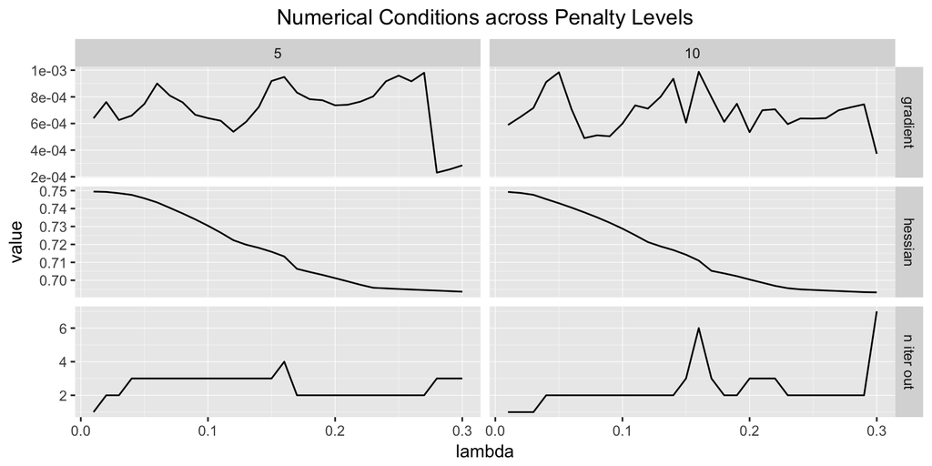

```r
r6_lslx$plot_numerical_condition()
```

The method `plot_information_criterion` shows the values of information criteria under all the penalty levels.

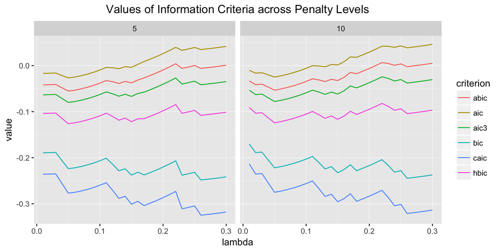

```r
r6_lslx$plot_information_criterion()
```

The method `plot_fit_indice` shows the values of fit indices under all the penalty levels.

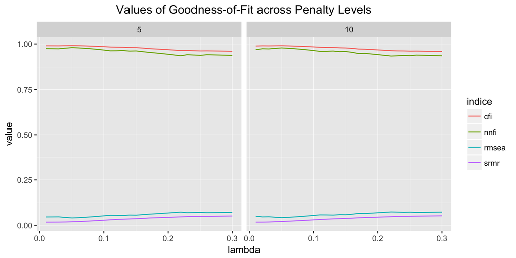

```r
r6_lslx$plot_fit_indice()
```

The method `plot_coefficient` shows the solution path of coefficients in the given block. The following code plots the solution paths of all coefficients in the block `y<-f`, which contains all the regression coeffcients from latent factors to observed variables (i.e., factor loadings).

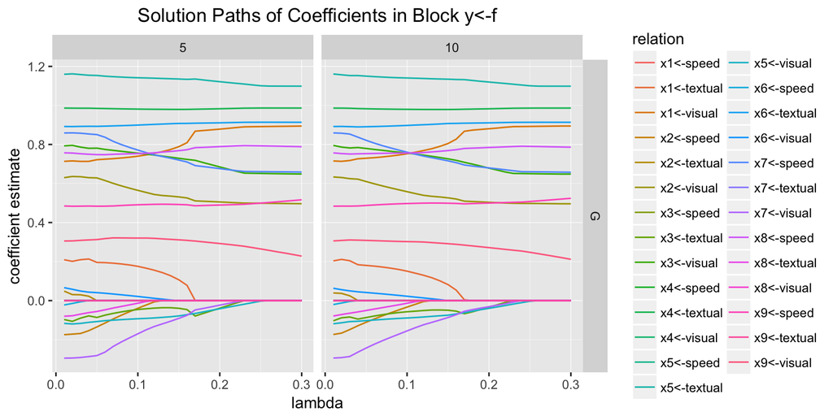

```r
r6_lslx$plot_coefficient(block = "y<-f")
```

## Objects Extraction

In `lslx`, many quantities related to SEM can be extracted by extract-related method. For example, the loading matrix can be obtained by

```r
r6_lslx$extract_coefficient_matrice(selector = "bic", block = "y<-f")
```

```
$G
   visual textual speed
x1  0.892   0.000 0.000
x2  0.499   0.000 0.000
x3  0.651   0.000 0.000
x4  0.000   0.987 0.000
x5  0.000   1.099 0.000
x6  0.000   0.914 0.000
x7  0.000   0.000 0.660
x8  0.000   0.000 0.792
x9  0.258   0.000 0.503
```

The model-implied covariance matrix and residual matrix can be obtained by

```r
r6_lslx$extract_implied_cov(selector = "bic")
```

```
$G
      x1    x2    x3    x4    x5    x6    x7    x8    x9
x1 1.337 0.445 0.581 0.397 0.442 0.368 0.191 0.230 0.376
x2 0.445 1.375 0.324 0.222 0.247 0.205 0.107 0.128 0.210
x3 0.581 0.324 1.264 0.290 0.323 0.268 0.140 0.168 0.274
x4 0.397 0.222 0.290 1.346 1.085 0.902 0.143 0.172 0.224
x5 0.442 0.247 0.323 1.085 1.653 1.005 0.160 0.192 0.249
x6 0.368 0.205 0.268 0.902 1.005 1.192 0.133 0.159 0.207
x7 0.191 0.107 0.140 0.143 0.160 0.133 1.182 0.523 0.387
x8 0.230 0.128 0.168 0.172 0.192 0.159 0.523 1.021 0.465
x9 0.376 0.210 0.274 0.224 0.249 0.207 0.387 0.465 0.979
```

```r
r6_lslx$extract_residual_cov(selector = "bic")
```

```
$G
          x1       x2        x3       x4       x5       x6       x7       x8       x9
x1 -0.021378  0.03741  0.000812 -0.10779  0.00167 -0.08705  0.10671 -0.03411 -0.08268
x2  0.037407 -0.00667 -0.126598  0.01292  0.03603 -0.04206  0.20373  0.01870 -0.03412
x3  0.000812 -0.12660 -0.011387  0.08148  0.21035  0.02417  0.05134 -0.04473 -0.09981
x4 -0.107787  0.01292  0.081476 -0.00521 -0.01311  0.00636 -0.07628  0.04654 -0.01947
x5  0.001670  0.03603  0.210351 -0.01311 -0.00650 -0.00990  0.01681  0.01114 -0.04584
x6 -0.087051 -0.04206  0.024170  0.00636 -0.00990 -0.00451 -0.01120 -0.00600 -0.02862
x7  0.106706  0.20373  0.051337 -0.07628  0.01681 -0.01120 -0.00124 -0.01207  0.01404
x8 -0.034108  0.01870 -0.044735  0.04654  0.01114 -0.00600 -0.01207 -0.00157  0.00741
x9 -0.082683 -0.03412 -0.099812 -0.01947 -0.04584 -0.02862  0.01404  0.00741 -0.03590
```